# Kümeleme Analizi

Öğrenci Stres Verileri Üzerinde Hiyerarşik ve K-Means Kümeleme

Veri Analizi Raporu

2025-12-31

**📊 Analiz Özeti:** Bu rapor, öğrenci stres verileri üzerinde kümeleme analizi yapmaktadır. Hiyerarşik kümeleme ve K-Means yöntemleri kullanılarak öğrenciler benzer özelliklerine göre gruplara ayrılmıştır.

**📌 Kullanılan Değişkenler:** Yaş, Nabız, Kan Basıncı (Sistolik/Diyastolik), Stres Seviyesi (Biosensor/Bildirim), Ders Saatleri, Proje Saatleri

# 1 Gerekli Kütüphaneler

```r
# Veri işleme ve görselleştirme
library(readxl)          # Excel dosyalarını okumak için
library(dplyr)           # Veri manipülasyonu için
library(ggplot2)         # Gelişmiş görselleştirme
library(plotly)          # İnteraktif grafikler

# Kümeleme analizi
library(cluster)         # Kümeleme fonksiyonları
library(factoextra)      # Kümeleme görselleştirme
library(dendextend)      # Dendrogram düzenleme

# İstatistiksel testler
library(rstatix)         # ANOVA ve diğer testler

# Diğer
library(circlize)        # Polar dendrogram
library(knitr)           # Tablo oluşturma
library(kableExtra)      # Gelişmiş tablolar
library(DT)              # İnteraktif tablolar
```

# 2 Veri Setinin Yüklenmesi

```r
# Excel dosyasını okuma
data <- read_excel("C:/Users/User/Desktop/cda_data_verianalizi/Kümeleme/duzenli_data_300gozlem.xlsx")

# Veri setinin ilk satırları
head(data) %>%
  kable(caption = "Veri Setinin İlk 6 Satırı") %>%
  kable_styling(bootstrap_options = c("striped", "hover", "condensed", "responsive"),
                full_width = FALSE,
                font_size = 12) %>%
  scroll_box(width = "100%")
```

Veri Setinin İlk 6 Satırı

| Ogrenci_ID | Yas | Cinsiyet | Nabiz | Kan_Basinci_Sistolik | Kan_Basinci_Diyastolik | Stress_Seviyesi_Biosensor | Stress_Seviyesi_Bildirim | Fiziksel_Aktivite | Uyku_Kalitesi | Ruh_Hali | Ders_Saatleri | Proje_Saatleri | Saglik_Riski_Seviyesi |
| --- | --- | --- | --- | --- | --- | --- | --- | --- | --- | --- | --- | --- | --- |
| 1 | 24 | 1 | 50.66322 | 122.1730 | 84.41986 | 3.137350 | 9.028669 | 3 | 2 | 3 | 34.520973 | 16.80096 | 2 |
| 2 | 21 | 0 | 57.92604 | 110.7784 | 75.69615 | 3.699078 | 5.819697 | 2 | 3 | 1 | 16.763846 | 15.79115 | 2 |
| 3 | 22 | 1 | 59.29422 | 109.3757 | 83.80381 | 6.785156 | 5.892360 | 1 | 2 | 3 | 44.203798 | 25.67844 | 2 |
| 4 | 24 | 1 | 76.82623 | 125.1422 | 78.09159 | 6.408509 | 6.884001 | 3 | 1 | 3 | 21.776645 | 20.80839 | 3 |
| 5 | 20 | 1 | 68.34277 | 107.5156 | 80.67494 | 7.264719 | 4.483450 | 2 | 1 | 3 | 8.964999 | 15.19404 | 2 |
| 6 | 22 | 1 | 61.74415 | 90.0000 | 84.45086 | 4.262518 | 6.825001 | 2 | 3 | 3 | 44.948229 | 15.65120 | 2 |

## 2.1 Veri Seti Hakkında Genel Bilgiler

```r
# Veri yapısı
cat("📊 Veri Seti Boyutu:", nrow(data), "gözlem,", ncol(data), "değişken\n\n")
```

```
📊 Veri Seti Boyutu: 300 gözlem, 14 değişken
```

```r
# Özet istatistikler
summary(data) %>%
  kable(caption = "Özet İstatistikler") %>%
  kable_styling(bootstrap_options = c("striped", "hover"),
                full_width = FALSE) %>%
  scroll_box(width = "100%", height = "400px")
```

Özet İstatistikler

|  | Ogrenci_ID | Yas | Cinsiyet | Nabiz | Kan_Basinci_Sistolik | Kan_Basinci_Diyastolik | Stress_Seviyesi_Biosensor | Stress_Seviyesi_Bildirim | Fiziksel_Aktivite | Uyku_Kalitesi | Ruh_Hali | Ders_Saatleri | Proje_Saatleri | Saglik_Riski_Seviyesi |
| --- | --- | --- | --- | --- | --- | --- | --- | --- | --- | --- | --- | --- | --- | --- |
|  | Min. : 1.00 | Min. :18.00 | Min. :0.0000 | Min. :50.00 | Min. : 90.0 | Min. : 60.00 | Min. :1.008 | Min. :1.002 | Min. :1.00 | Min. :1.000 | Min. :1.0 | Min. : 5.00 | Min. : 0.00 | Min. :1.000 |
|  | 1st Qu.: 75.75 | 1st Qu.:19.00 | 1st Qu.:0.0000 | 1st Qu.:63.74 | 1st Qu.:108.9 | 1st Qu.: 73.39 | 1st Qu.:3.231 | 1st Qu.:3.265 | 1st Qu.:1.00 | 1st Qu.:2.000 | 1st Qu.:2.0 | 1st Qu.:23.02 | 1st Qu.:11.39 | 1st Qu.:2.000 |
|  | Median :150.50 | Median :21.00 | Median :1.0000 | Median :70.43 | Median :119.3 | Median : 78.98 | Median :5.368 | Median :5.376 | Median :2.00 | Median :2.000 | Median :2.0 | Median :29.78 | Median :14.88 | Median :2.000 |
|  | Mean :150.50 | Mean :21.04 | Mean :0.5067 | Mean :70.39 | Mean :119.6 | Mean : 79.48 | Mean :5.433 | Mean :5.480 | Mean :1.89 | Mean :2.283 | Mean :2.2 | Mean :29.67 | Mean :14.92 | Mean :1.957 |
|  | 3rd Qu.:225.25 | 3rd Qu.:23.00 | 3rd Qu.:1.0000 | 3rd Qu.:76.36 | 3rd Qu.:130.6 | 3rd Qu.: 85.10 | 3rd Qu.:7.636 | 3rd Qu.:7.713 | 3rd Qu.:2.00 | 3rd Qu.:3.000 | 3rd Qu.:3.0 | 3rd Qu.:36.71 | 3rd Qu.:18.35 | 3rd Qu.:2.000 |
|  | Max. :300.00 | Max. :24.00 | Max. :1.0000 | Max. :99.65 | Max. :160.7 | Max. :104.10 | Max. :9.862 | Max. :9.929 | Max. :3.00 | Max. :3.000 | Max. :3.0 | Max. :59.86 | Max. :32.72 | Max. :3.000 |

# 3 Kümeleme İçin Veri Hazırlığı

**⚠️ Önemli:** Kümeleme analizinde sadece seçilmiş nicel değişkenler kullanılacaktır.

```r
# Kullanılacak değişkenler
analiz_degiskenleri <- c("Yas", "Nabiz", "Kan_Basinci_Sistolik",
                         "Kan_Basinci_Diyastolik", "Stress_Seviyesi_Biosensor",
                         "Stress_Seviyesi_Bildirim", "Ders_Saatleri",
                         "Proje_Saatleri")

# Kümeleme için veri seçimi
kumeleme_data <- data[, analiz_degiskenleri]

# Eksik gözlem kontrolü
eksik_gozlem <- sum(is.na(kumeleme_data))
cat("Eksik Gözlem Sayısı:", eksik_gozlem, "\n")
```

```
Eksik Gözlem Sayısı: 0
```

```r
# Eksik gözlemlerin temizlenmesi (varsa)
kumeleme_data <- na.omit(kumeleme_data)

cat("✅ Temiz Veri Seti:", nrow(kumeleme_data), "gözlem\n")
```

```
✅ Temiz Veri Seti: 300 gözlem
```

## 3.1 Korelasyon Analizi

```r
# Korelasyon matrisi
cor_matrix <- cor(kumeleme_data)

# Korelasyon tablosu
cor_matrix %>%
  kable(caption = "Değişkenler Arası Korelasyon Matrisi", digits = 3) %>%
  kable_styling(bootstrap_options = c("striped", "hover"),
                full_width = FALSE) %>%
  scroll_box(width = "100%")
```

Değişkenler Arası Korelasyon Matrisi

|  | Yas | Nabiz | Kan_Basinci_Sistolik | Kan_Basinci_Diyastolik | Stress_Seviyesi_Biosensor | Stress_Seviyesi_Bildirim | Ders_Saatleri | Proje_Saatleri |
| --- | --- | --- | --- | --- | --- | --- | --- | --- |
| Yas | 1.000 | -0.088 | -0.061 | 0.122 | 0.019 | 0.006 | -0.112 | -0.086 |
| Nabiz | -0.088 | 1.000 | -0.034 | -0.098 | 0.183 | 0.005 | 0.017 | -0.004 |
| Kan_Basinci_Sistolik | -0.061 | -0.034 | 1.000 | 0.025 | -0.076 | -0.030 | 0.008 | -0.067 |
| Kan_Basinci_Diyastolik | 0.122 | -0.098 | 0.025 | 1.000 | -0.077 | 0.003 | -0.060 | 0.009 |
| Stress_Seviyesi_Biosensor | 0.019 | 0.183 | -0.076 | -0.077 | 1.000 | -0.043 | -0.162 | 0.075 |
| Stress_Seviyesi_Bildirim | 0.006 | 0.005 | -0.030 | 0.003 | -0.043 | 1.000 | 0.084 | -0.046 |
| Ders_Saatleri | -0.112 | 0.017 | 0.008 | -0.060 | -0.162 | 0.084 | 1.000 | -0.007 |
| Proje_Saatleri | -0.086 | -0.004 | -0.067 | 0.009 | 0.075 | -0.046 | -0.007 | 1.000 |

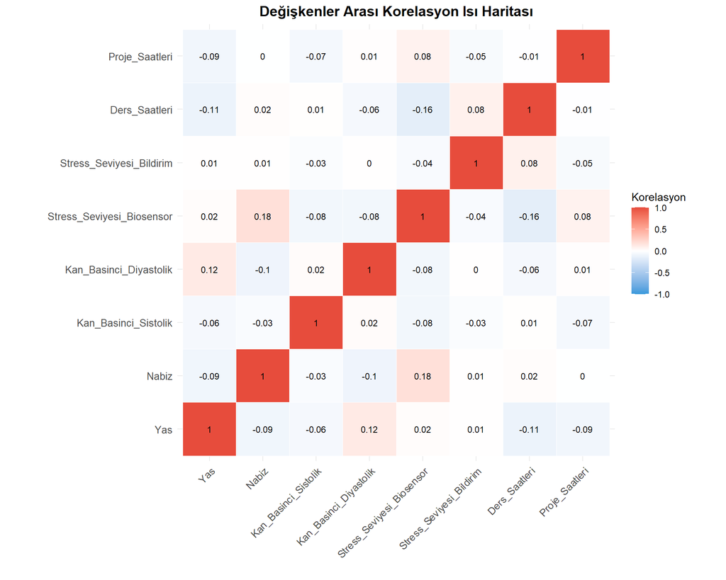

```r
# Korelasyon ısı haritası
library(reshape2)
melted_cor <- melt(cor_matrix)

ggplot(data = melted_cor, aes(x = Var1, y = Var2, fill = value)) +
  geom_tile(color = "white") +
  geom_text(aes(label = round(value, 2)), color = "black", size = 3) +
  scale_fill_gradient2(low = "#3498db", high = "#e74c3c", mid = "white",
                       midpoint = 0, limit = c(-1, 1), space = "Lab",
                       name = "Korelasyon") +
  theme_minimal() +
  theme(axis.text.x = element_text(angle = 45, hjust = 1, vjust = 1, size = 10),
        axis.text.y = element_text(size = 10),
        plot.title = element_text(hjust = 0.5, face = "bold", size = 14)) +
  labs(title = "Değişkenler Arası Korelasyon Isı Haritası",
       x = "", y = "") +
  coord_fixed()
```

# 4 Hiyerarşik Kümeleme Analizi

## 4.1 Uzaklık Matrisi ve İlk Dendrogram

```r
# Euclidean uzaklık matrisi
d <- dist(kumeleme_data, method = "euclidean")

# Hiyerarşik kümeleme (Ward yöntemi)
fit <- hclust(d, method = "ward.D")

# İlk dendrogram
dend <- as.dendrogram(fit)
```

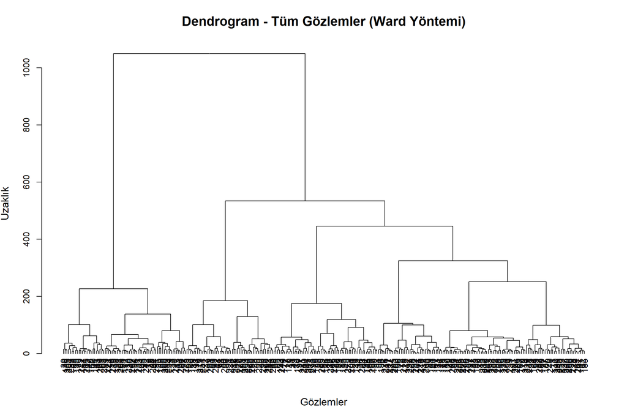

```r
par(mar = c(5, 4, 4, 2))
plot(dend, main = "Dendrogram - Tüm Gözlemler (Ward Yöntemi)",
     xlab = "Gözlemler", ylab = "Uzaklık",
     cex.main = 1.5, cex.lab = 1.2)
```

## 4.2 Renkli Dendrogram (3 Küme)

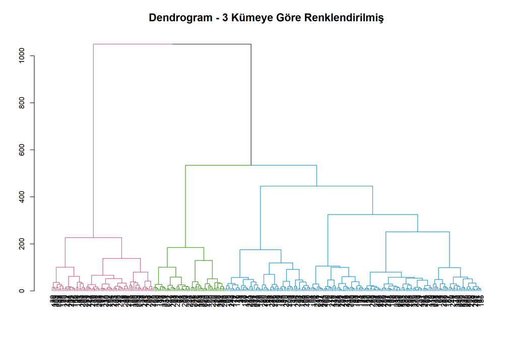

```r
par(mar = c(5, 4, 4, 2))
plot(color_branches(dend, k = 3),
     main = "Dendrogram - 3 Kümeye Göre Renklendirilmiş",
     cex.main = 1.5)
```

## 4.3 Aykırı Gözlem Kontrolü

**💡 Not:** Dendrogram incelenerek aykırı gözlemler tespit edilebilir. Gerekirse bu gözlemler analiz dışı bırakılabilir.

```r
# Şimdilik aykırı gözlem çıkarmadan devam ediyoruz
# Eğer aykırı gözlem varsa, şu şekilde çıkarılabilir:
# aykiri_gozlem <- c(25, 150)  # Örnek satır numaraları
# kumeleme_data2 <- kumeleme_data[-aykiri_gozlem, ]
# data2 <- data[-aykiri_gozlem, ]

kumeleme_data2 <- kumeleme_data
data2 <- data

cat("✓ Analiz için kullanılan gözlem sayısı:", nrow(kumeleme_data2), "\n")
```

```
✓ Analiz için kullanılan gözlem sayısı: 300
```

## 4.4 Gelişmiş Dendrogram Görselleştirmeleri

```r
# Yeni uzaklık matrisi
d2 <- dist(kumeleme_data2, method = "euclidean")
fit2 <- hclust(d2, method = "ward.D")
dend2 <- as.dendrogram(fit2)

# Etiketleme
labels(dend2) <- paste("Ogr_", data2$Ogrenci_ID[order.dendrogram(dend2)], sep = "")
```

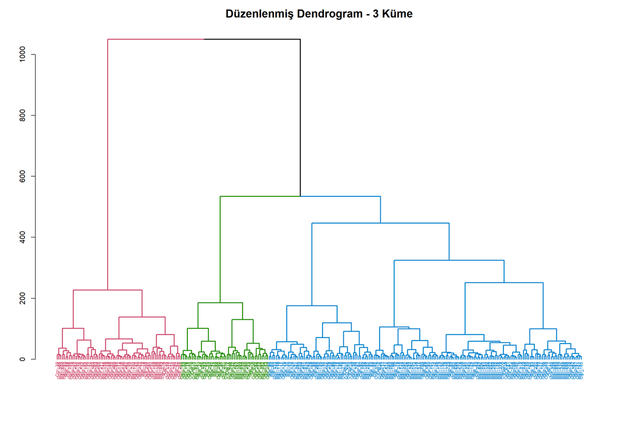

```r
# Düzenlenmiş dendrogram
geneldend <- dend2 %>%
  set("branches_lwd", 2) %>%
  set("branches_k_color", k = 3) %>%
  set("labels_cex", 0.6) %>%
  set("labels_colors", k = 3)

par(mar = c(8, 4, 3, 2))
plot(geneldend, main = "Düzenlenmiş Dendrogram - 3 Küme",
     cex.main = 1.5)
```

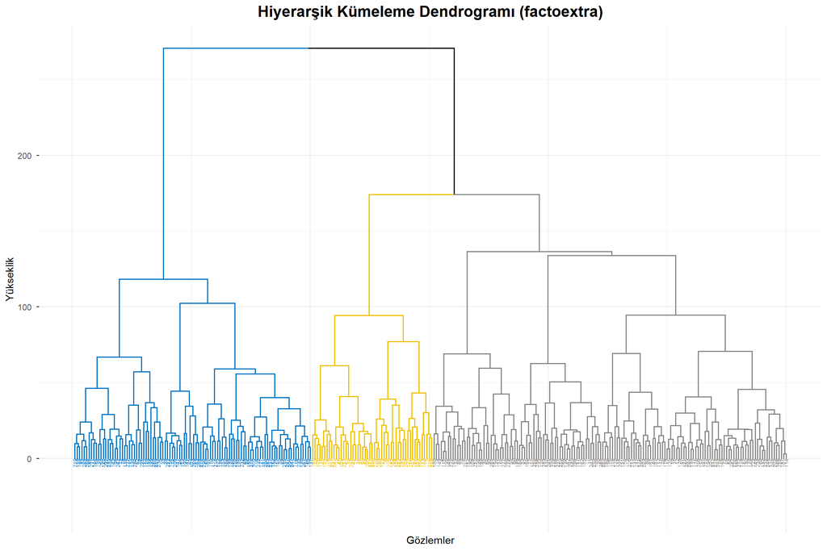

```r
# factoextra ile dendrogram
res.hc <- hclust(d2, method = "ward.D2")
fviz_dend(res.hc, cex = 0.4, k = 3, palette = "jco",
          main = "Hiyerarşik Kümeleme Dendrogramı (factoextra)",
          xlab = "Gözlemler", ylab = "Yükseklik",
          ggtheme = theme_minimal()) +
  theme(plot.title = element_text(hjust = 0.5, size = 16, face = "bold"))
```

## 4.5 Polar Dendrogram

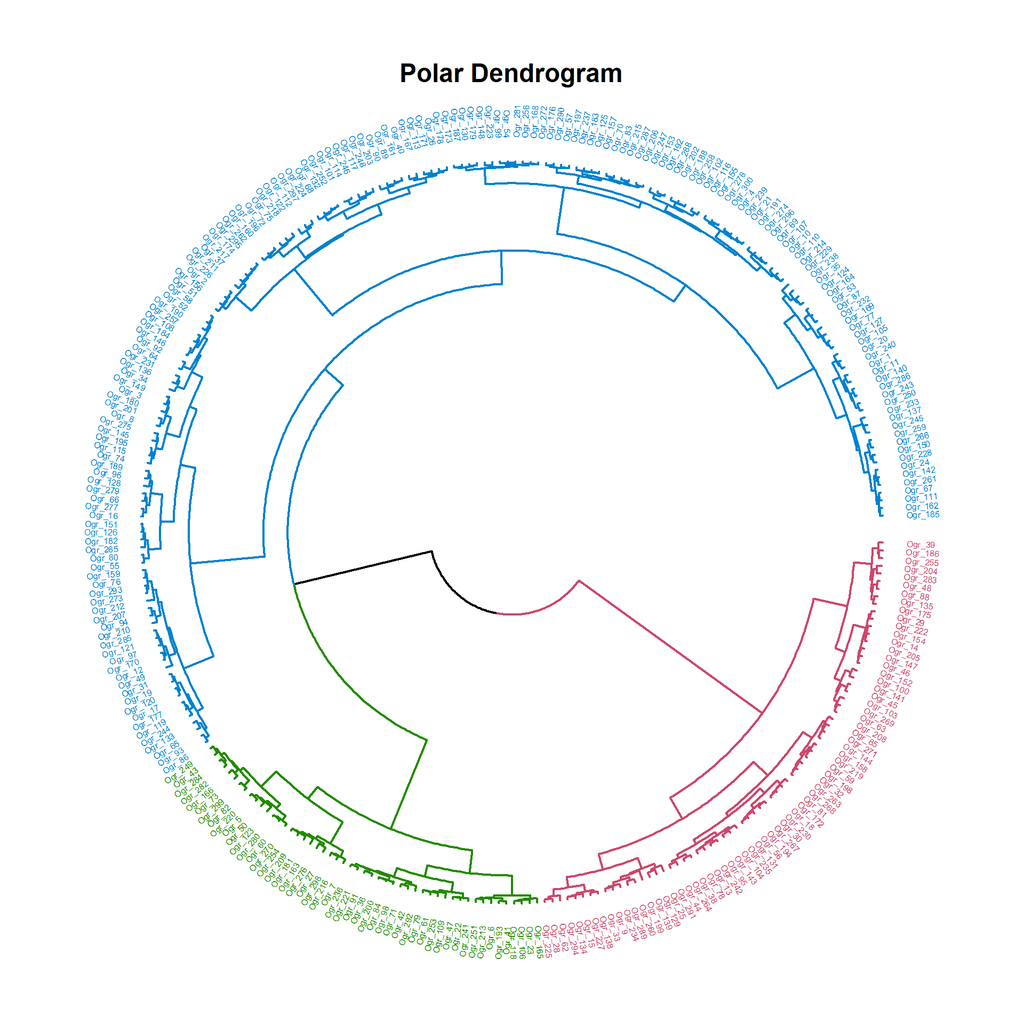

```r
# Polar eksende dendrogram
par(mar = c(1, 1, 3, 1))
geneldend %>%
  set("labels_cex", 0.5) %>%
  set("labels_colors", k = 3) %>%
  circlize_dendrogram(dend_track_height = 0.7)
title("Polar Dendrogram", line = -1, cex.main = 1.5)
```

# 5 K-Means Kümeleme Analizi

## 5.1 Optimal Küme Sayısının Belirlenmesi

### 5.1.1 Elbow (Dirsek) Yöntemi

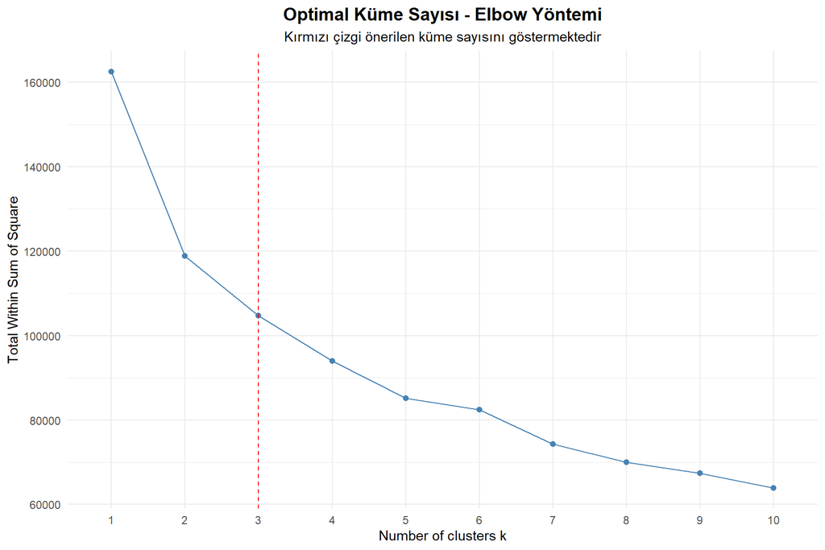

```r
fviz_nbclust(kumeleme_data2, kmeans, method = "wss", k.max = 10) +
  geom_vline(xintercept = 3, linetype = 2, color = "red") +
  labs(title = "Optimal Küme Sayısı - Elbow Yöntemi",
       subtitle = "Kırmızı çizgi önerilen küme sayısını göstermektedir") +
  theme_minimal() +
  theme(plot.title = element_text(hjust = 0.5, size = 14, face = "bold"),
        plot.subtitle = element_text(hjust = 0.5, size = 11))
```

### 5.1.2 Silhouette Yöntemi

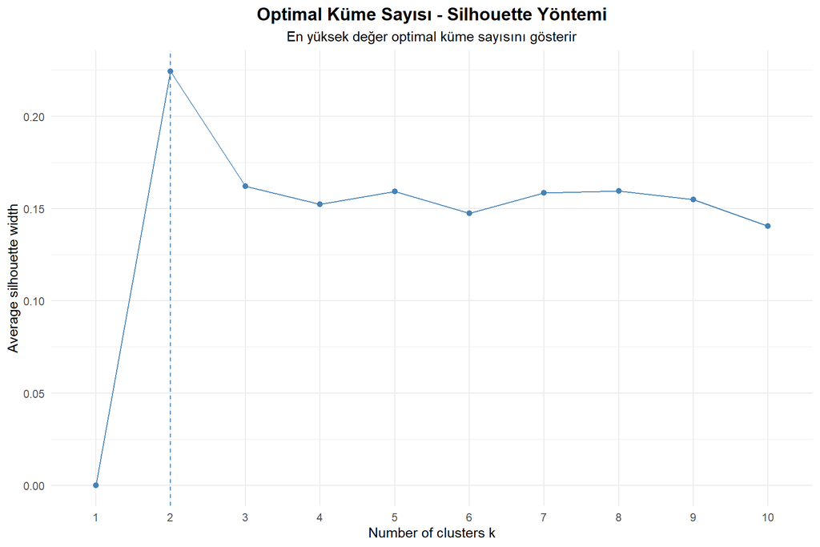

```r
fviz_nbclust(kumeleme_data2, kmeans, method = "silhouette", k.max = 10) +
  labs(title = "Optimal Küme Sayısı - Silhouette Yöntemi",
       subtitle = "En yüksek değer optimal küme sayısını gösterir") +
  theme_minimal() +
  theme(plot.title = element_text(hjust = 0.5, size = 14, face = "bold"),
        plot.subtitle = element_text(hjust = 0.5, size = 11))
```

## 5.2 K-Means Kümeleme (k=3)

```r
# K-means kümeleme
set.seed(95739487)
km.res <- kmeans(kumeleme_data2, centers = 3, iter.max = 100,
                 nstart = 25, algorithm = "Lloyd")

# Küme büyüklükleri
cat("📊 Her Kümedeki Gözlem Sayısı:\n")
```

```
📊 Her Kümedeki Gözlem Sayısı:
```

```r
print(table(km.res$cluster))
```

```
  1   2   3
 98 117  85
```

```r
cat("\n")
```

```r
# Küme merkezleri
cat("🎯 Küme Merkezleri (Final Cluster Centers):\n\n")
```

```
🎯 Küme Merkezleri (Final Cluster Centers):
```

```r
t(km.res$centers) %>%
  kable(caption = "Küme Merkezleri", digits = 2) %>%
  kable_styling(bootstrap_options = c("striped", "hover", "condensed"),
                full_width = FALSE) %>%
  column_spec(1, bold = TRUE, background = "#f8f9fa")
```

Küme Merkezleri

|  | 1 | 2 | 3 |
| --- | --- | --- | --- |
| Yas | 21.04 | 20.98 | 21.12 |
| Nabiz | 66.09 | 71.01 | 74.49 |
| Kan_Basinci_Sistolik | 112.61 | 134.38 | 107.47 |
| Kan_Basinci_Diyastolik | 79.96 | 80.06 | 78.14 |
| Stress_Seviyesi_Biosensor | 4.93 | 5.27 | 6.23 |
| Stress_Seviyesi_Bildirim | 5.65 | 5.43 | 5.36 |
| Ders_Saatleri | 38.05 | 28.18 | 22.04 |
| Proje_Saatleri | 15.83 | 14.53 | 14.42 |

## 5.3 Kümeleme Sonuçlarının Görselleştirilmesi

### 5.3.1 2 Boyutlu Gösterim (PCA)

[figure not shown]

```r
# clusplot ile görselleştirme
clusplot(kumeleme_data2, km.res$cluster,
         main = 'K-Means Kümeleme - 2 Boyutlu Gösterim (İlk İki Temel Bileşen)',
         color = TRUE,
         shade = TRUE,
         labels = 2,
         lines = 0,
         cex = 1.2,
         col.clus = c("#e74c3c", "#3498db", "#2ecc71"),
         col.p = c("#e74c3c", "#3498db", "#2ecc71"))
```

### 5.3.2 İnteraktif Görselleştirme

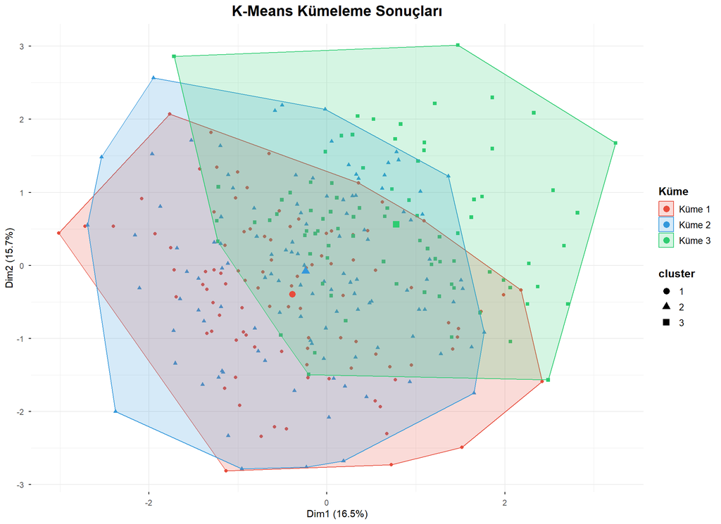

```r
# factoextra ile gelişmiş görselleştirme
fviz_cluster(km.res, data = kumeleme_data2,
             palette = c("#e74c3c", "#3498db", "#2ecc71"),
             geom = "point",
             ellipse.type = "convex",
             ggtheme = theme_minimal(),
             main = "K-Means Kümeleme Sonuçları") +
  theme(plot.title = element_text(hjust = 0.5, size = 16, face = "bold"),
        legend.position = "right",
        legend.title = element_text(size = 12, face = "bold"),
        legend.text = element_text(size = 10)) +
  scale_color_manual(values = c("#e74c3c", "#3498db", "#2ecc71"),
                     name = "Küme",
                     labels = c("Küme 1", "Küme 2", "Küme 3")) +
  scale_fill_manual(values = c("#e74c3c", "#3498db", "#2ecc71"),
                    name = "Küme",
                    labels = c("Küme 1", "Küme 2", "Küme 3"))
```

## 5.4 Küme Üyeliklerinin Veriye Eklenmesi

```r
# Küme üyeliklerini veriye ekleme
data2$cluster <- as.factor(km.res$cluster)
kumeleme_data2$cluster <- as.factor(km.res$cluster)

cat("✅ Küme üyelikleri veriye başarıyla eklendi!\n")
```

```
✅ Küme üyelikleri veriye başarıyla eklendi!
```

# 6 İstatistiksel Analiz (ANOVA)

**📈 Amaç:** Her değişken için kümeler arasında anlamlı fark olup olmadığını test etmek. **H₀:** Kümeler arasında anlamlı fark yoktur. **H₁:** En az iki küme arasında anlamlı fark vardır.

```r
# ANOVA testleri
anova_sonuclari <- data.frame(
  Degisken = character(),
  F_Degeri = numeric(),
  p_Degeri = numeric(),
  Anlamlilik = character(),
  stringsAsFactors = FALSE
)

degiskenler <- c("Yas", "Nabiz", "Kan_Basinci_Sistolik", "Kan_Basinci_Diyastolik",
                 "Stress_Seviyesi_Biosensor", "Stress_Seviyesi_Bildirim",
                 "Ders_Saatleri", "Proje_Saatleri")

for (deg in degiskenler) {
  formula_str <- paste(deg, "~ cluster")
  aov_result <- aov(as.formula(formula_str), data = data2)
  summary_aov <- summary(aov_result)

  f_value <- summary_aov[[1]]["cluster", "F value"]
  p_value <- summary_aov[[1]]["cluster", "Pr(>F)"]

  anlamli <- ifelse(p_value < 0.001, "***",
                    ifelse(p_value < 0.01, "**",
                           ifelse(p_value < 0.05, "*", "NS")))

  anova_sonuclari <- rbind(anova_sonuclari,
                           data.frame(Degisken = deg,
                                      F_Degeri = f_value,
                                      p_Degeri = p_value,
                                      Anlamlilik = anlamli))
}
```

## 6.1 ANOVA Sonuçları Tablosu

```r
anova_sonuclari %>%
  mutate(p_Degeri = format(p_Degeri, scientific = TRUE, digits = 3)) %>%
  kable(caption = "ANOVA Test Sonuçları (*** p<0.001, ** p<0.01, * p<0.05, NS: Anlamlı değil)",
        col.names = c("Değişken", "F Değeri", "p Değeri", "Anlamlılık"),
        digits = 3) %>%
  kable_styling(bootstrap_options = c("striped", "hover", "condensed", "responsive"),
                full_width = FALSE) %>%
  column_spec(4, bold = TRUE,
              color = ifelse(anova_sonuclari$p_Degeri < 0.05, "green", "red"))
```

ANOVA Test Sonuçları (*** p<0.001, ** p<0.01, * p<0.05, NS: Anlamlı değil)

| Değişken | F Değeri | p Değeri | Anlamlılık |
| --- | --- | --- | --- |
| Yas | 0.109 | 8.96e-01 | NS |
| Nabiz | 21.380 | 2.11e-09 | *** |
| Kan_Basinci_Sistolik | 263.338 | 1.64e-66 | *** |
| Kan_Basinci_Diyastolik | 1.266 | 2.83e-01 | NS |
| Stress_Seviyesi_Biosensor | 6.559 | 1.63e-03 | ** |
| Stress_Seviyesi_Bildirim | 0.329 | 7.20e-01 | NS |
| Ders_Saatleri | 94.820 | 1.43e-32 | *** |
| Proje_Saatleri | 2.278 | 1.04e-01 | NS |

## 6.2 ANOVA Sonuçlarının Görselleştirilmesi

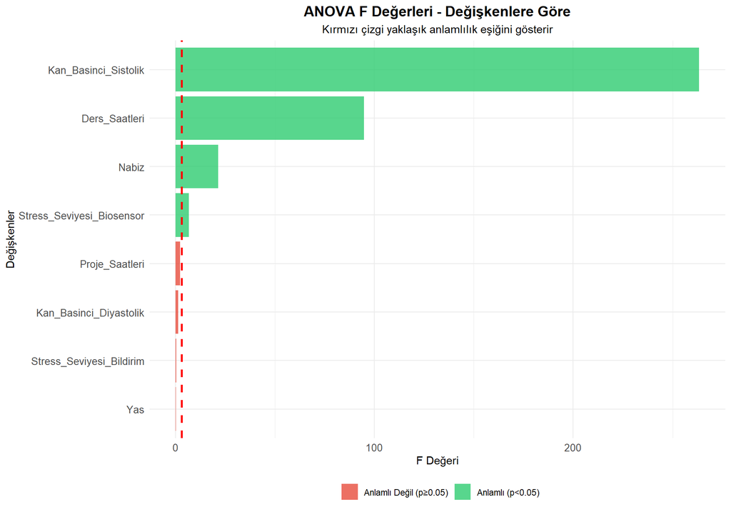

```r
anova_sonuclari$log_p <- -log10(anova_sonuclari$p_Degeri)

ggplot(anova_sonuclari, aes(x = reorder(Degisken, F_Degeri), y = F_Degeri, fill = p_Degeri < 0.05)) +
  geom_bar(stat = "identity", alpha = 0.8) +
  geom_hline(yintercept = 3.0, linetype = "dashed", color = "red", size = 1) +
  scale_fill_manual(values = c("FALSE" = "#e74c3c", "TRUE" = "#2ecc71"),
                    labels = c("Anlamlı Değil (p≥0.05)", "Anlamlı (p<0.05)"),
                    name = "") +
  coord_flip() +
  theme_minimal() +
  labs(title = "ANOVA F Değerleri - Değişkenlere Göre",
       subtitle = "Kırmızı çizgi yaklaşık anlamlılık eşiğini gösterir",
       x = "Değişkenler",
       y = "F Değeri") +
  theme(plot.title = element_text(hjust = 0.5, size = 14, face = "bold"),
        plot.subtitle = element_text(hjust = 0.5, size = 11),
        legend.position = "bottom",
        axis.text = element_text(size = 10))
```

# 7 Küme Karakteristikleri

## 7.1 Küme İstatistikleri

```r
# Her küme için ortalama değerler
cluster_means <- aggregate(. ~ cluster,
                          data = data2[, c(analiz_degiskenleri, "cluster")],
                          FUN = mean)

cluster_means %>%
  kable(caption = "Kümelere Göre Ortalama Değerler", digits = 2) %>%
  kable_styling(bootstrap_options = c("striped", "hover", "condensed"),
                full_width = FALSE) %>%
  column_spec(1, bold = TRUE, background = "#f8f9fa") %>%
  scroll_box(width = "100%")
```

Kümelere Göre Ortalama Değerler

| cluster | Yas | Nabiz | Kan_Basinci_Sistolik | Kan_Basinci_Diyastolik | Stress_Seviyesi_Biosensor | Stress_Seviyesi_Bildirim | Ders_Saatleri | Proje_Saatleri |
| --- | --- | --- | --- | --- | --- | --- | --- | --- |
| 1 | 21.04 | 66.09 | 112.61 | 79.96 | 4.93 | 5.65 | 38.05 | 15.83 |
| 2 | 20.98 | 71.01 | 134.38 | 80.06 | 5.27 | 5.43 | 28.18 | 14.53 |
| 3 | 21.12 | 74.49 | 107.47 | 78.14 | 6.23 | 5.36 | 22.04 | 14.42 |

```r
# Her küme için standart sapmalar
cluster_sd <- aggregate(. ~ cluster,
                       data = data2[, c(analiz_degiskenleri, "cluster")],
                       FUN = sd)

cluster_sd %>%
  kable(caption = "Kümelere Göre Standart Sapmalar", digits = 2) %>%
  kable_styling(bootstrap_options = c("striped", "hover", "condensed"),
                full_width = FALSE) %>%
  column_spec(1, bold = TRUE, background = "#f8f9fa") %>%
  scroll_box(width = "100%")
```

Kümelere Göre Standart Sapmalar

| cluster | Yas | Nabiz | Kan_Basinci_Sistolik | Kan_Basinci_Diyastolik | Stress_Seviyesi_Biosensor | Stress_Seviyesi_Bildirim | Ders_Saatleri | Proje_Saatleri |
| --- | --- | --- | --- | --- | --- | --- | --- | --- |
| 1 | 2.04 | 7.99 | 8.99 | 9.98 | 2.67 | 2.64 | 6.76 | 5.41 |
| 2 | 2.02 | 8.85 | 8.77 | 8.71 | 2.44 | 2.41 | 9.08 | 4.94 |
| 3 | 2.01 | 9.49 | 9.38 | 8.87 | 2.33 | 2.72 | 7.67 | 5.09 |

## 7.2 İnteraktif Küme İstatistikleri

```r
data2 %>%
  group_by(cluster) %>%
  summarise(
    N = n(),
    Ort_Yas = mean(Yas),
    Ort_Nabiz = mean(Nabiz),
    Ort_Sistolik = mean(Kan_Basinci_Sistolik),
    Ort_Diyastolik = mean(Kan_Basinci_Diyastolik),
    Ort_Stress_Bio = mean(Stress_Seviyesi_Biosensor),
    Ort_Stress_Bil = mean(Stress_Seviyesi_Bildirim),
    Ort_Ders = mean(Ders_Saatleri),
    Ort_Proje = mean(Proje_Saatleri)
  ) %>%
  datatable(caption = "Küme Özet İstatistikleri (İnteraktif Tablo)",
            options = list(pageLength = 10, scrollX = TRUE),
            rownames = FALSE) %>%
  formatRound(columns = 2:10, digits = 2)
```

| cluster | N | Ort_Yas | Ort_Nabiz | Ort_Sistolik | Ort_Diyastolik | Ort_Stress_Bio | Ort_Stress_Bil | Ort_Ders | Ort_Proje |
| --- | --- | --- | --- | --- | --- | --- | --- | --- | --- |
| 1 | 98 | 21.04081632653061 | 66.08926050704756 | 112.6147464032454 | 79.95797385376716 | 4.933678795859312 | 5.648215199163873 | 38.05498842959611 | 15.83067873963347 |
| 2 | 117 | 20.98290598290598 | 71.0123769991424 | 134.3757725772652 | 80.05922948448256 | 5.272045818700239 | 5.429019976374383 | 28.17772333381948 | 14.52994895734759 |
| 3 | 85 | 21.11764705882353 | 74.49415073637496 | 107.4674357610297 | 78.14236412067655 | 6.228900378010554 | 5.356882845342928 | 22.04335109268298 | 14.41951048629738 |

# 8 Boxplot Görselleştirmeleri

## 8.1 Ana Değişkenler İçin Boxplot’lar

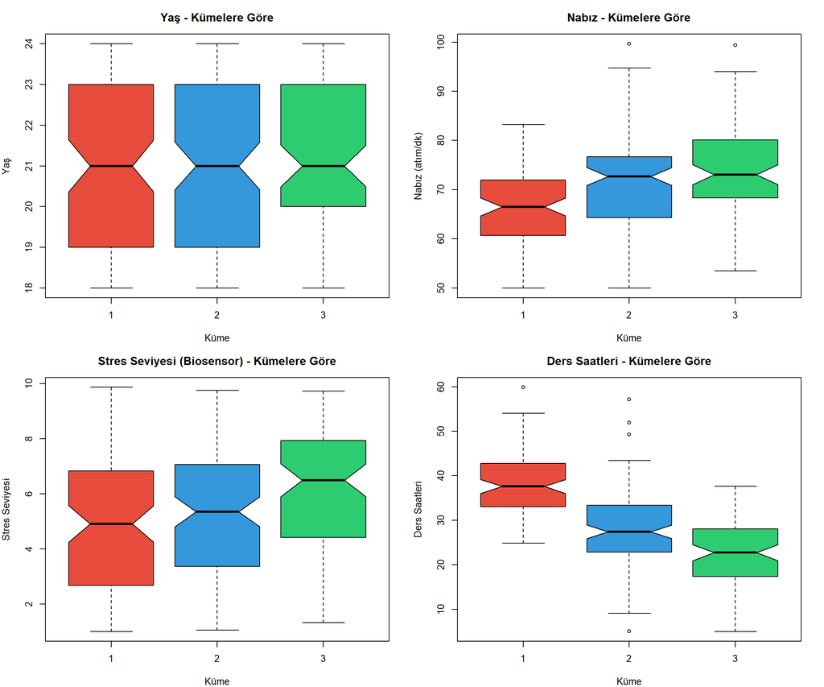

```r
par(mfrow = c(2, 2), mar = c(4, 4, 3, 2))

# Yaş
boxplot(Yas ~ cluster, data = data2,
        main = "Yaş - Kümelere Göre",
        xlab = "Küme", ylab = "Yaş",
        col = c("#e74c3c", "#3498db", "#2ecc71"),
        border = "black", notch = TRUE)

# Nabız
boxplot(Nabiz ~ cluster, data = data2,
        main = "Nabız - Kümelere Göre",
        xlab = "Küme", ylab = "Nabız (atım/dk)",
        col = c("#e74c3c", "#3498db", "#2ecc71"),
        border = "black", notch = TRUE)

# Stres Seviyesi (Biosensor)
boxplot(Stress_Seviyesi_Biosensor ~ cluster, data = data2,
        main = "Stres Seviyesi (Biosensor) - Kümelere Göre",
        xlab = "Küme", ylab = "Stres Seviyesi",
        col = c("#e74c3c", "#3498db", "#2ecc71"),
        border = "black", notch = TRUE)

# Ders Saatleri
boxplot(Ders_Saatleri ~ cluster, data = data2,
        main = "Ders Saatleri - Kümelere Göre",
        xlab = "Küme", ylab = "Ders Saatleri",
        col = c("#e74c3c", "#3498db", "#2ecc71"),
        border = "black", notch = TRUE)
```

```r
par(mfrow = c(1, 1))
```

## 8.2 Kan Basıncı Değişkenleri

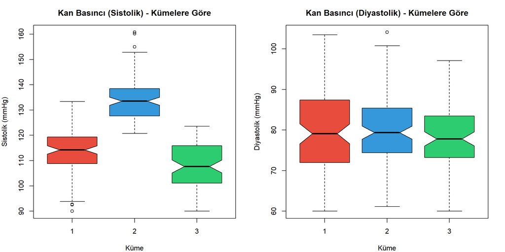

```r
par(mfrow = c(1, 2), mar = c(4, 4, 3, 2))

# Sistolik
boxplot(Kan_Basinci_Sistolik ~ cluster, data = data2,
        main = "Kan Basıncı (Sistolik) - Kümelere Göre",
        xlab = "Küme", ylab = "Sistolik (mmHg)",
        col = c("#e74c3c", "#3498db", "#2ecc71"),
        border = "black", notch = TRUE)

# Diyastolik
boxplot(Kan_Basinci_Diyastolik ~ cluster, data = data2,
        main = "Kan Basıncı (Diyastolik) - Kümelere Göre",
        xlab = "Küme", ylab = "Diyastolik (mmHg)",
        col = c("#e74c3c", "#3498db", "#2ecc71"),
        border = "black", notch = TRUE)
```

```r
par(mfrow = c(1, 1))
```

## 8.3 Çalışma Saatleri

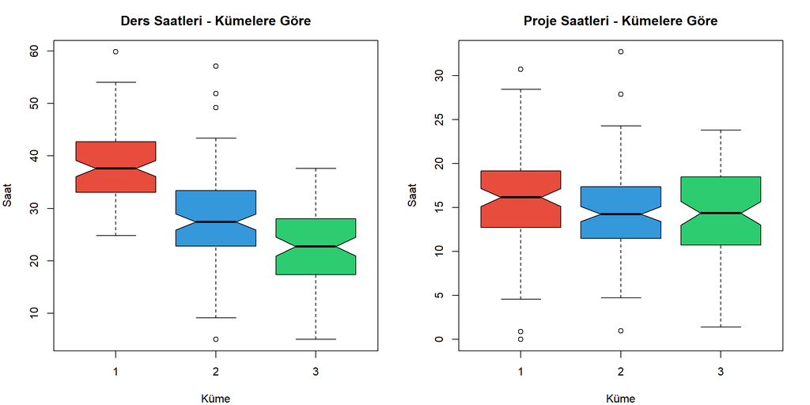

```r
par(mfrow = c(1, 2), mar = c(4, 4, 3, 2))

# Ders Saatleri
boxplot(Ders_Saatleri ~ cluster, data = data2,
        main = "Ders Saatleri - Kümelere Göre",
        xlab = "Küme", ylab = "Saat",
        col = c("#e74c3c", "#3498db", "#2ecc71"),
        border = "black", notch = TRUE)

# Proje Saatleri
boxplot(Proje_Saatleri ~ cluster, data = data2,
        main = "Proje Saatleri - Kümelere Göre",
        xlab = "Küme", ylab = "Saat",
        col = c("#e74c3c", "#3498db", "#2ecc71"),
        border = "black", notch = TRUE)
```

```r
par(mfrow = c(1, 1))
```

## 8.4 ggplot2 ile Gelişmiş Boxplot’lar

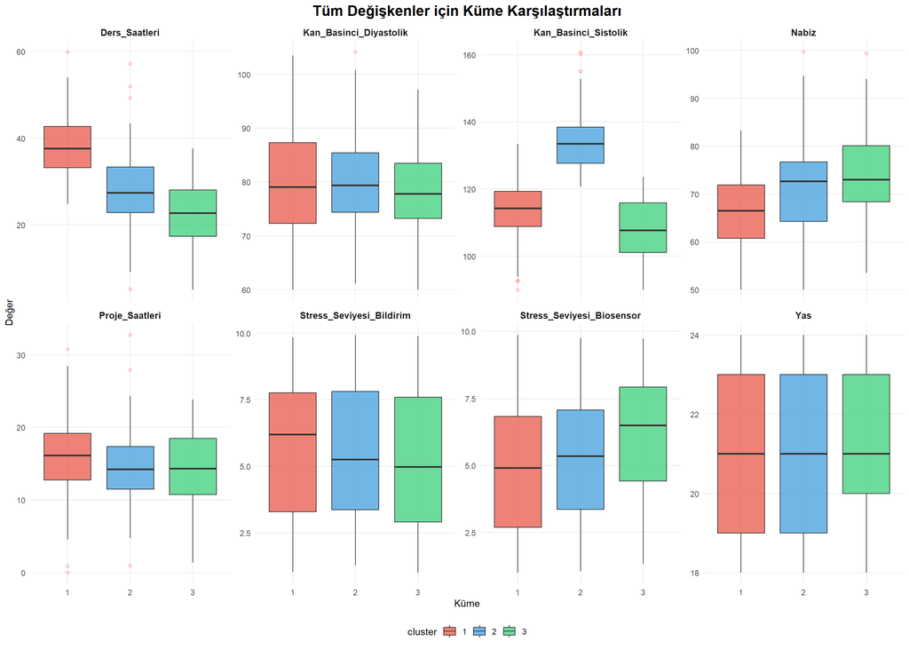

```r
library(tidyr)
library(gridExtra)

# Veriyi uzun formata çevirme
data_long <- data2 %>%
  select(cluster, all_of(analiz_degiskenleri)) %>%
  pivot_longer(cols = -cluster, names_to = "Degisken", values_to = "Deger")

# Boxplot
p <- ggplot(data_long, aes(x = cluster, y = Deger, fill = cluster)) +
  geom_boxplot(alpha = 0.7, outlier.colour = "red", outlier.shape = 1) +
  facet_wrap(~ Degisken, scales = "free_y", ncol = 4) +
  scale_fill_manual(values = c("#e74c3c", "#3498db", "#2ecc71")) +
  theme_minimal() +
  labs(title = "Tüm Değişkenler için Küme Karşılaştırmaları",
       x = "Küme",
       y = "Değer") +
  theme(plot.title = element_text(hjust = 0.5, size = 16, face = "bold"),
        strip.text = element_text(size = 10, face = "bold"),
        legend.position = "bottom",
        axis.text.x = element_text(size = 9),
        panel.grid.minor = element_blank())

print(p)
```

# 9 Küme Profilleri (Radar Grafikleri)

```r
library(fmsb)

# Verileri normalize etme (0-100 arası)
normalize <- function(x) {
  return(100 * (x - min(x)) / (max(x) - min(x)))
}

# Küme ortalamalarını normalize et
cluster_means_norm <- cluster_means
for (col in analiz_degiskenleri) {
  cluster_means_norm[[col]] <- normalize(cluster_means[[col]])
}
```

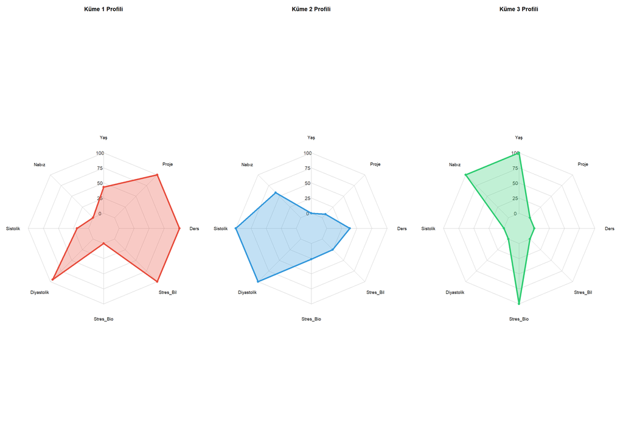

```r
par(mfrow = c(1, 3), mar = c(1, 1, 3, 1))

# Her küme için radar grafiği
colors <- c("#e74c3c", "#3498db", "#2ecc71")

for (i in 1:3) {
  # Radar grafiği için veri hazırlama
  radar_data <- rbind(
    rep(100, 8),  # Max değerler
    rep(0, 8),    # Min değerler
    cluster_means_norm[cluster_means_norm$cluster == i, analiz_degiskenleri]
  )

  # Kısa değişken isimleri
  colnames(radar_data) <- c("Yaş", "Nabız", "Sistolik", "Diyastolik",
                            "Stres_Bio", "Stres_Bil", "Ders", "Proje")

  radarchart(radar_data,
             axistype = 1,
             pcol = colors[i],
             pfcol = scales::alpha(colors[i], 0.3),
             plwd = 3,
             cglcol = "grey",
             cglty = 1,
             axislabcol = "grey20",
             caxislabels = seq(0, 100, 25),
             cglwd = 0.8,
             vlcex = 0.9,
             title = paste("Küme", i, "Profili"))
}
```

```r
par(mfrow = c(1, 1))
```

# 10 Sonuçların Kaydedilmesi

```r
# Küme üyeliklerini içeren veriyi kaydetme
write.csv(data2, "kumeleme_sonuclari.csv", row.names = FALSE)
cat("✅ Kümeleme sonuçları 'kumeleme_sonuclari.csv' dosyasına kaydedildi.\n\n")
```

```
✅ Kümeleme sonuçları 'kumeleme_sonuclari.csv' dosyasına kaydedildi.
```

```r
# Küme istatistiklerini kaydetme
write.csv(cluster_means, "kume_ortalamalar.csv", row.names = FALSE)
cat("✅ Küme ortalamaları 'kume_ortalamalar.csv' dosyasına kaydedildi.\n\n")
```

```
✅ Küme ortalamaları 'kume_ortalamalar.csv' dosyasına kaydedildi.
```

```r
# ANOVA sonuçlarını kaydetme
write.csv(anova_sonuclari, "anova_sonuclari.csv", row.names = FALSE)
cat("✅ ANOVA sonuçları 'anova_sonuclari.csv' dosyasına kaydedildi.\n")
```

```
✅ ANOVA sonuçları 'anova_sonuclari.csv' dosyasına kaydedildi.
```

# 11 Özet ve Yorumlar

## 11.1 📊 Analiz Özeti

### 11.1.3 ANOVA Sonuçları

Aşağıdaki değişkenler kümeler arasında anlamlı fark göstermiştir (p<0.05):

```r
anlamli_degiskenler <- anova_sonuclari %>%
  filter(p_Degeri < 0.05) %>%
  arrange(p_Degeri)

if (nrow(anlamli_degiskenler) > 0) {
  anlamli_degiskenler %>%
    mutate(p_Degeri = format(p_Degeri, scientific = TRUE, digits = 3)) %>%
    kable(caption = "Kümeler Arası Anlamlı Fark Gösteren Değişkenler") %>%
    kable_styling(bootstrap_options = c("striped", "hover"),
                  full_width = FALSE)
} else {
  cat("Hiçbir değişken kümeler arasında anlamlı fark göstermemiştir.\n")
}
```

Kümeler Arası Anlamlı Fark Gösteren Değişkenler

| Degisken | F_Degeri | p_Degeri | Anlamlilik | log_p |
| --- | --- | --- | --- | --- |
| Kan_Basinci_Sistolik | 263.337635 | 1.64e-66 | *** | 65.785437 |
| Ders_Saatleri | 94.819811 | 1.43e-32 | *** | 31.845976 |
| Nabiz | 21.380225 | 2.11e-09 | *** | 8.674831 |
| Stress_Seviyesi_Biosensor | 6.558789 | 1.63e-03 | ** | 2.787335 |

### 11.1.4 Küme Büyüklükleri

```r
table(data2$cluster) %>%
  as.data.frame() %>%
  setNames(c("Küme", "Gözlem Sayısı")) %>%
  mutate(Yuzde = paste0(round(100 * `Gözlem Sayısı` / sum(`Gözlem Sayısı`), 1), "%")) %>%
  kable(caption = "Kümelerdeki Gözlem Dağılımı") %>%
  kable_styling(bootstrap_options = c("striped", "hover"),
                full_width = FALSE)
```

Kümelerdeki Gözlem Dağılımı

| Küme | Gözlem Sayısı | Yuzde |
| --- | --- | --- |
| 1 | 98 | 32.7% |
| 2 | 117 | 39% |
| 3 | 85 | 28.3% |

## 11.2 💡 Yorumlar ve Öneriler

1. **Küme Karakterizasyonu:** Her kümenin ortalama değerlerine bakarak kümelere anlamlı isimler verilebilir (örn: “Yüksek Stres Grubu”, “Dengeli Grup”, vb.)
2. **Değişken Önemi:** ANOVA sonuçları, hangi değişkenlerin kümeleri en iyi ayırt ettiğini göstermektedir
3. **Aykırı Değerler:** Boxplot’larda görülen aykırı değerler detaylı incelenmelidir
4. **Validasyon:** Farklı seed değerleri ve başlangıç noktaları ile sonuçların tutarlılığı kontrol edilebilir
5. **İleri Analiz:** Kümelere göre ek analizler (lojistik regresyon, karar ağaçları) yapılabilir

**📅 Rapor Tarihi:** 2025-12-31  
**👤 Analiz:** Kümeleme Analizi - Öğrenci Stres Verileri  
**📊 Gözlem Sayısı:** 300  
**🔬 Küme Sayısı:** 3  
**✨ Durum:** Analiz Tamamlandı